# Econometrics 1

Tutorial 1

Elisa Alonso Herrero

## Plan for sessions

We will have 6 sessions:

- Friday, **18th Sept**: Introduction
- Friday, **25th Sept**: Problem set 1
- Friday, **2nd Oct**: Problem set 2
- Friday, **9th Oct**: Problem set 3 $\rightarrow$ Do you want to move this?
- Friday, **16th Oct**: Problem set 4
- Friday, **23rd Oct**: Revision session

## Four problem sets

- You will work in **groups of 3** (+ one group of 2), randomly chosen
- I will provide you the PS $\approx$ 1 week in advance.
- No written responses will be uploaded, important to pay attention and take notes in the sessions

**Instructions**

- Subject of any email for the class should start with `[metrics1]`
- One person from each group should send me an email with (1) a pdf called `LASTNAME1+LASTNAME2+....pdf`, and (2) if you need to submit code, one R/R-markdown script named similarly
- Document should be created with R Markdown/Quarto or Overleaf/LaTeX
- Deadline: 1pm a day before each tutorial. Late submissions: hourly discount rate of 5%.
- Interpretation of results is very important !!
- Important to know/contribute to all parts of the PS

## Evaluation

Problem sets + Class participation $= 20\%$ of the total grade (equal weights)

- **Problem sets:** One randomly selected PS will be evaluated among the 4, grade will be same for all members of the group.
- **Class participation:**
  - Questions and participation in class
  - Answering Problem Set questions in class
  - Attendance and punctuality.

## Office Hours

- **Sessions**: Sep 18th, Sep 25th, Oct 2nd, Oct 9th, Oct 16th, Oct 23rd (11-12h)
- Please post your questions here before each session: [**link**](https://docs.google.com/document/d/1P9UAPox5l6JGTzJ4hbZB4uqrMo1_-vHPEPRPBPApwUQ/edit?usp=sharing)
- This will help me to prepare better answers for your questions and work as a “public good” as your classmates might share similar doubts.

# Why do we need econometrics?

## Econometrics provides statistical methods to answer economic questions

- **Descriptive Q**: asks about how things are (or were) in reality, e.g. Has economic inequality increased since 1960?
- **Causal Q**: asks what would have happened in a counterfactual world, e.g. How do increases in the minimum wage affect employment?
- **Forecasting Q**: asks what will happen in the future, e.g. What will the unemployment rate be next quarter?
  - Accurate prediction may be possible without knowing anything about the underlying model / causal relationships in the data
  - ML is a popular tool for this

## Answering descriptive questions is already hard

Problem 1: selection bias, due to non-random sampling, non-response, attrition…

**Example**

RQ: How has the distribution of income in the US changed over time? Sample: Survey of workers (e.g. CPS, PSID, etc.)

- Best case scenario: **randomly selected** sample from population $\to$ just need to account for the fact that the sample might have different characteristics from the population by chance
- Normal scenario: sample is **not** representative of the population (e.g. certain types of workers are more likely to respond to the survey) $\to$ misleading results!

## Answering descriptive questions is hard

Problem 2: measurement error, due to misreporting, misclassification, etc.

Problem 3: missing data, especially if the missingness is not random (e.g. top 1% earners are less likely to respond to surveys)

Problem 4: sampling variability, due to the fact that we only observe a sample of the population $\to$ we will learn how to quantify this uncertainty using **confidence intervals** and **hypothesis tests**

## Causal questions are even harder

Golden rule: *“Correlation is not causation”*

Causal questions make us think about the **counterfactual outcome** (how would things have been under different/counterfactual circumstances?)

**Example**

RQ: What is the effect on your earnings from going to PSE instead of Science Po?

- **Descriptive:** how much do PSE students earn after graduation?
- **Counterfactual:** how much would PSE students have earned if they had instead gone to Sciences Po?

**Counterfactuals can’t be learned from seeing data alone.** We need additional assumptions to learn about them.

## What you will learn in PPD

The econometrics sequence (E1, E2, E3, ATM) will teach you how to answer causal questions using observational data.

**This course**<sup>1</sup>

- Univariate and multivariate regression models
  - Estimation, assumptions, interpretations
- Sample selection, data problems (focus of *Measurement*)
- Inference, i.e. how to quantify uncertainty in your estimates
- Omitted variable bias and instrumental variables
[^1]: The tutorial slides may introduce some extra notation and a more formal discussion of the content of E1, with the aim of helping you bridge the gap between E1 and E2.

# The building blocks of linear regressions

## Joint distributions

The joint distribution of two random variables shows the values and associated frequencies of two variables simultaneously.

**Formal definition**

The joint distribution of two random variables $X$ and $Y$ describes the probability of observing different combinations of values of $X$ and $Y$, i.e. $P(X=x, Y=y)$ for all possible values of $x$ and $y$.

## Joint distributions

When describing a **joint distribution**, we are interested in the **relationship** between two variables: this can be characterized by the covariance

$$\widehat{\text{Cov}}(x,y) = \frac{1}{n}\sum_{i=1}^n (x_i - \bar x)(y_i - \bar y)$$

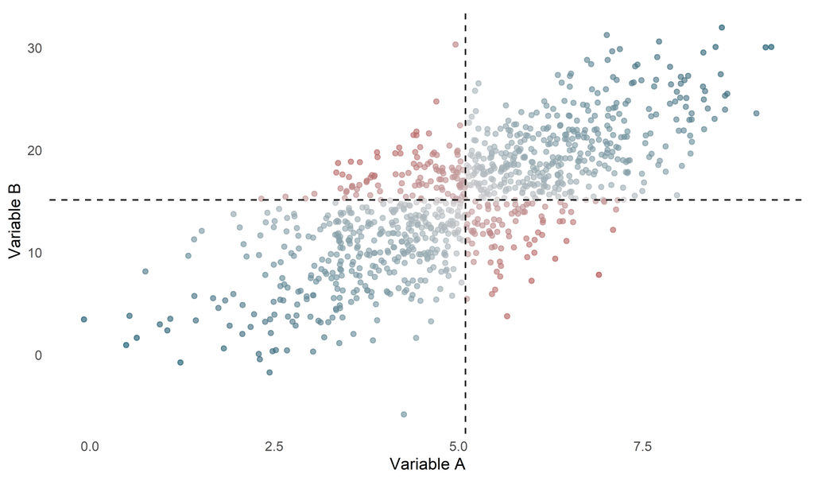

*If **y** tends to be **large** relative to its mean when **x** is **large** relative to its mean, their **covariance** is **positive***

*Conversely, if **one** tends to be **large** when the **other** tends to be **low**, the **covariance** is **negative***

## Covariance

[figure not shown]

## Correlation

- One disadvantage of covariance is that it is not standardized, so it is hard to compare across different pairs of variables
- To net out the covariance from the scale of the variables, we can compute the correlation coefficient:
  $$\text{Corr}(x,y) = \frac{\text{Cov}(x,y)}{SD(x) SD(y)}$$

where $SD(x)$ and $SD(y)$ are the standard deviations of $x$ and $y$, respectively

- The correlation coefficient is always between -1 and 1

## Correlation

[figure not shown]

## Correlation

The problem with correlation is that it can hide very different relationships

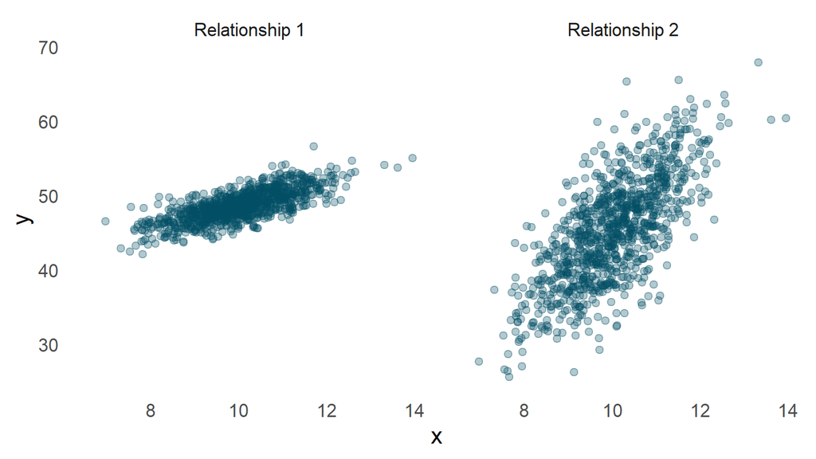

$\to$ One is less noisy but flatter

$\to$ One is noisier but steeper

**Both have a correlation of .75**

## Correlation

The problem with correlation is that it can hide very different relationships

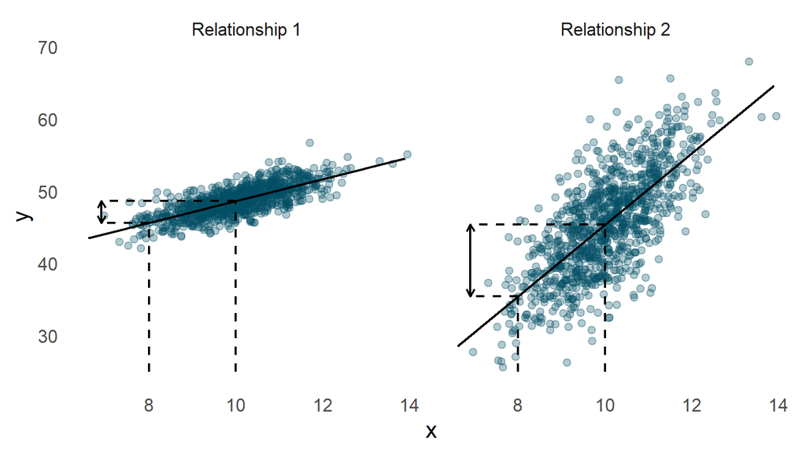

**But a given increase in x is not associated with a same increase in y!**

## Introducing regressions

Consider the following dataset that we saw in the R class:

First 5 rows

| country | ige | gini |
| --- | --- | --- |
| Denmark | 0.15 | 0.3781796 |
| Norway | 0.17 | 0.3250102 |
| Finland | 0.18 | 0.3779868 |
| Canada | 0.19 | 0.4631237 |
| Australia | 0.26 | 0.4385511 |

The data contains **2 variables** at the **country level**:

1. **IGE:** Intergenerational elasticity, which captures the % average increase in child income for a 1% increase in parental income
2. **Gini:** Gini index of income inequality between 0 (everybody has the same income) and 1 (a single individual has all the income)

## Introducing regressions

We use regressions to summarize the relationship between two variables (or more) with a line. But how do we find the “best” line?

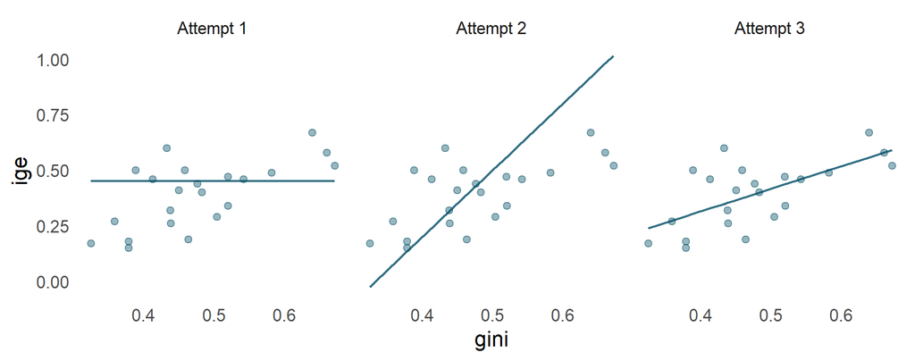

## Introducing regressions

We try to **minimize the distance** between each point and our line

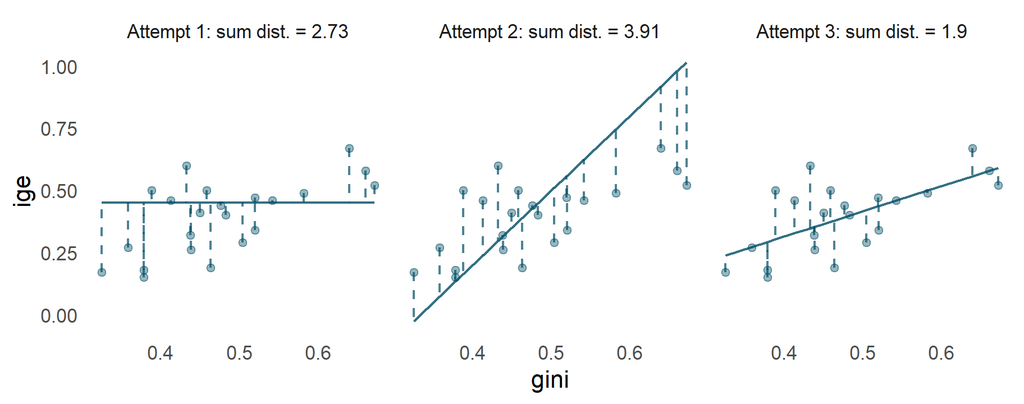

## Introducing regressions

Take for instance the 20<sup>th</sup> observation: Peru

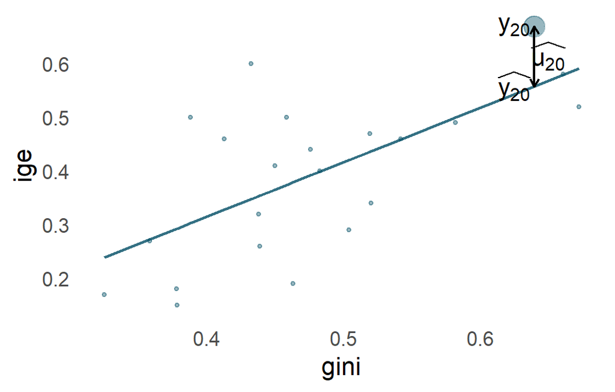

And consider the following **notations**:

- We denote $y_i$ the ige of the $i^{\text{th}}$ country
- We denote $x_i$ the gini of the $i^{\text{th}}$ country
- We denote $\widehat{y_i}$ the value of the $y$ coordinate of our line for $x = x_i$

$\rightarrow$ The distance between the $i^{\text{th}}$ y value and the line is $\widehat{u_i} = y_i - \widehat{y_i}$

## Introducing regressions

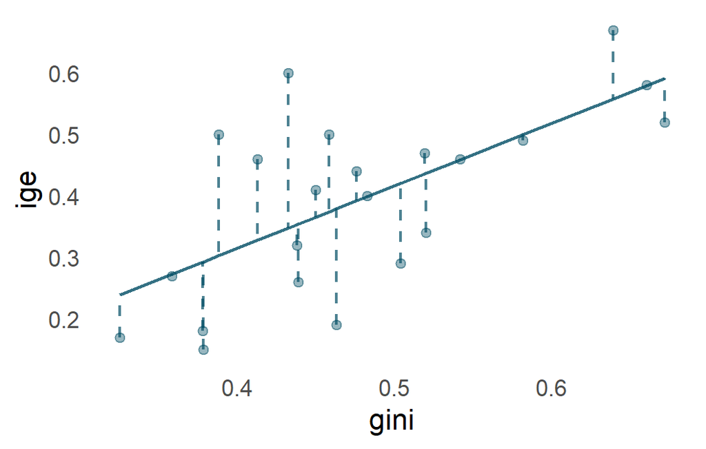

- $\widehat{u_i}$ being the distance between a point $y_i$ and its corresponding value on the line $\widehat{y_i}$, we can write:

$$y_i = \widehat{y_i} + \widehat{u_i}$$

- And because $\widehat{y_i}$ is a **straight line**, it can be expressed as

$$\widehat{y_i} = \hat{\beta_0} + \hat{\beta_1}x_i$$

## Introducing regressions

- **Combining** these two **definitions** yields the equation:

$$y_i = \hat{\beta_0} + \hat{\beta_1}x_i + \widehat{u_i} \begin{cases} y_i = \widehat{y_i} + \widehat{u_i}& \text{Definition of distance}\\
\widehat{y_i} = \hat{\beta_0} + \hat{\beta_1}x_i & \text{Definition of the line}
\end{cases}$$

- Depending on the values of $\hat{\beta_0}$ and $\hat{\beta_1}$, the value of every $\widehat{u_i}$ will change

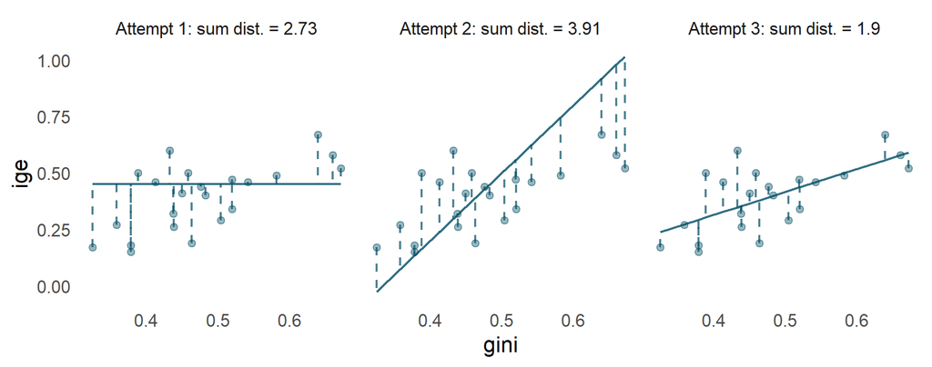

**Attempt 1:** $\hat{\beta_0}$ is too high and $\hat{\beta_1}$ is too low $\rightarrow$ $\widehat{u_i}$ are large

**Attempt 2:** $\hat{\beta_0}$ is too low and $\hat{\beta_1}$ is too high $\rightarrow$ $\widehat{u_i}$ are large

**Attempt 3:** both $\hat{\beta_0}$ and $\hat{\beta_1}$ seem right $\rightarrow$ $\widehat{u_i}$ are low

## Linear regression model

More formally, a linear regression model is a statistical model used to describe the relationship between a dependent variable $Y$ and one or more independent variables $X_{1,}\dots, X_n$.

The general form can be written as:
$$Y= \beta_{0} + \beta_{1}X_{1}+ \dots + \beta_{n}X_{n} + u$$
where $u$ is the error term, which captures the variation in $Y$ that is not explained by the independent variables.

## Coefficients estimation: OLS

- We want to find the values of $\hat{\beta_0}$ and $\hat{\beta_1}$ that **minimize** the overall **distance** between the points and the line

$$\min_{\hat{\beta_0}, \hat{\beta_1}}\sum_{i=1}^{n}\widehat{u_i}^2$$

- Note that we square ($\widehat{u_i}$) to avoid that positive and negative values compensate each other
- This method is what we call **Ordinary Least Squares (OLS)**
- To solve this **optimization problem**, we need to express $\widehat{u_i}$ it in terms of beta $\hat{\beta_0}$ and $\hat{\beta_1}$

$$y_i = \hat{\beta_0} + \hat{\beta_1}x_i + \widehat{u_i} \Longleftrightarrow \widehat{u_i} = y_i -\hat{\beta_0} - \hat{\beta_1}x_i$$

## Coefficients estimation: OLS

Our minimization problem can now be rewritten as:

$$\min_{\hat{\beta_0}, \hat{\beta_1}}\sum_{i=1}^{n}(y_i -\hat{\beta_0} - \hat{\beta_1}x_i)^2$$

$$\begin{align}
\frac{\partial}{\partial\hat{\beta_0}} = 0 & \:\: \Longleftrightarrow \:\: -2\sum_{i=1}^n(y_i - \hat{\beta_0} - \hat{\beta_1}x_i) = 0 \\
\frac{\partial}{\partial\hat{\beta_1}} = 0 & \:\: \Longleftrightarrow \:\: -2\sum_{i=1}^n x_i(y_i - \hat{\beta_0} - \hat{\beta_1}x_i) = 0
\end{align}$$

- Rearranging the first equation yields

$$\sum_{i=1}^ny_i - n\hat{\beta_0} - \sum_{i=1}^n\hat{\beta_1}x_i = 0 \:\: \Longleftrightarrow \:\: \hat{\beta_0} =\bar{y} - \hat{\beta_1}\bar{x}$$

## Coefficients estimation: OLS

- Replacing $\hat{\beta_0}$ in the second equation by its new expression writes

$$-2\sum_{i=1}^n x_i(y_i - \hat{\beta_0} - \hat{\beta_1}x_i) = 0 \:\: \Longleftrightarrow \:\: -2\sum_{i=1}^n x_i\left[y_i - (\bar{y} - \hat{\beta_1}\bar{x}) - \hat{\beta_1}x_i\right] = 0$$

- And by expanding the terms and rearranging we obtain

$$\hat{\beta_1} = \frac{\sum_{i = 1}^n(x_i-\bar{x})(y_i-\bar{y})}{\sum_{i = 1}^n(x_i-\bar{x})^2}$$

- Notice that multiplying the nominator and the denominator by $1/n$ yields:

$$\hat{\beta_1} = \frac{\text{Cov}(x_i, y_i)}{\text{Var}(x_i)} \:\:\:\:\:\:\:\:\: ; \:\:\:\:\:\:\:\:\: \hat{\beta_0} = \bar{y} - \frac{\text{Cov}(x_i, y_i)}{\text{Var}(x_i)} \times\bar{x}$$

# A step back: key statistical concepts

It’s important to remember the differences between key statistical quantities in order to understand OLS

## Sample vs population

Econometrics is about learning about a **population** from a **sample**.

**Population:** the entire group of interest, from which we would like to draw conclusions

- E.g. all workers in France

**Sample:** the data we actually observe, as drawn from a population

- E.g. Responses from an earnings survey of PSE/SP grads.
- We view sampled data as random, and the full population as fixed.

## Population-side: parameter and estimand

**(Target) Parameter:** unknown quantity of interest of the true population

- E.g. Average earnings effect from going to PSE instead of Sciences Po
- A fixed number, but not directly computable

**Estimand:** a real number which is a function of the population distribution, which we would like to learn about from the sample

- E.g. Difference in earnings between all PSE and Sciences Po graduates
- A fixed number, could be directly computable if we had access to the full population data

$\Rightarrow$ Relating a parameter you are interested in to an estimand is called **identification**. This is the main focus of E2.

## Sample-side: estimator and estimate

**Estimator:** a function of the variables we actually see.

- E.g. Difference in earnings between surveyed PSE/SP students.
- A random object, because the sampled data are random.
- The process of learning about the estimand from the estimator is called **statistical inference**.

**Estimate**: specific *value* you get from applying the estimator to *one particular* sample

- E.g. “in our sample of 526 students, $\Delta\overline{\text{earnings}} = \$340$”

## An example all together

Back to our regression of intergenerational elasticity (IGE) on inequality (Gini): $IGE = \beta_0 + \beta_1 \cdot Gini + u$

**Parameter**: the *true* causal effect of inequality on mobility $\beta_1$, unknown

**Estimand**: the population regression slope — a function of the *observed* joint distribution of (Gini, IGE)

$$\beta_1^{OLS} = \frac{\text{Cov}(Gini, IGE)}{\text{Var}(Gini)}$$

**Identification**: $\beta_1^{OLS} = \beta_1$ requires $E(u \mid Gini) = 0$ $\to$ we will see why in a second! **Estimator**: the sample analog of the estimand

$$\hat\beta_1 = \frac{\sum_{i=1}^n(x_i-\bar x)(y_i-\bar y)}{\sum_{i=1}^n(x_i-\bar x)^2}$$

**Estimate**: the actual number, from *our* sample of countries

## Why does identification need $E(u \mid Gini) = 0$?

Start from the OLS estimator for the slope:

$$\hat\beta_1 = \frac{\sum_{i=1}^n(x_i-\bar x)(y_i-\bar y)}{\sum_{i=1}^n(x_i-\bar x)^2}$$

Now suppose the **true** model is $y_i = \beta_0 + \beta_1 x_i + u_i$.

Averaging over $i$: $\bar y = \beta_0+\beta_1\bar x + \bar u$

Subtracting from the model equation: $y_i - \bar y = \beta_1(x_i-\bar x) + (u_i - \bar u)$

## Why does identification need $E(u \mid Gini) = 0$?

Substitute this into the numerator of $\hat\beta_1$:

$$\sum_{i=1}^n (x_i-\bar x)(y_i-\bar y) = \beta_1\underbrace{\sum_{i=1}^n(x_i-\bar x)^2}_{\text{cancels with denominator}} + \sum_{i=1}^n(x_i-\bar x)(u_i-\bar u)$$

Divide through by $\sum(x_i-\bar x)^2$:

$$\hat\beta_1 = \beta_1 + \underbrace{\frac{\sum_{i=1}^n(x_i-\bar x)(u_i-\bar u)}{\sum_{i=1}^n(x_i-\bar x)^2}}_{\text{bias, in this sample}}$$

$\to$ OLS can’t distinguish “the effect of $x$” from “whatever’s correlated with $x$ inside $u$” $\to$ But this bias term will be zero **on average** if $E(u \mid x) = 0$ !

## Properties of a good estimator

An estimator is a function of the (random) sample, so it is itself a random variable and it has a distribution. But not all estimators are equally good. We care about the following properties:

**Unbiasedness**: $E(\hat\beta_1) = \beta_1$: the expected value of the estimator is equal to the value of the parameter of interest

**Consistency**: $\hat\beta \overset{p}{\to} \beta$: as the sample size increases, the estimator converges in probability to the true parameter

**Efficiency**: an estimator is efficient if, among all unbiased estimators, it has the smallest variance

## Key assumptions for OLS

1. **Linearity**: the relationship between $Y$ and $X$ is linear

2. **Random sampling**: the data are a random sample from the population of interest
3. **Zero conditional mean**: $E(u \mid X) = 0$ (strict exogeneity)
4. **No perfect collinearity**: no independent variable is a perfect linear function of the others
5. **Homoskedasticity**: $Var(u \mid X) = \sigma^2$ (constant variance of the error term)

## Key assumptions for OLS properties

| Assumptions | Unbiased $E[\hat\beta]=\beta$ | Consistent $\hat\beta \overset{p}{\to} \beta$ | BLUE (Gauss-Markov) |
| --- | --- | --- | --- |
| Linearity | ✔️ | ✔️ | ✔️ |
| Random sampling | ✔️ | ✔️ | ✔️ |
| Zero conditional mean | ✔️ | ✔️ | ✔️ |
| No perfect multicollinearity | ✔️ | ✔️ | ✔️ |
| Homoskedasticity: $V(u \mid X) = \sigma^2$ |  |  | ✔️ |

# Interpretation

The most important thing for your homeworks and exams is to be able to interpret the coefficients of a regression.

## Interpreting the coefficient

The coefficient of $X$ tells us how the *mean* of $Y$ changes as $X$ changes. But the exact interpretation depends on the **scale** of $Y$ and $X$:

| $Y$ | $X$ | Interpretation | Example |
| --- | --- | --- | --- |
| Level | Level | Change in $Y$ for a one-unit change in $X$ *(constant marginal effect)* | $IGE_i = \beta_0+\beta_1 Gini_i+u_i$: a one-point increase in Gini is associated with a $\beta_1$-unit change in IGE |
| Binary | Level | Change in $P(Y=1)$ for a one-unit change in $X$, i.e. a *linear probability model* (LPM) | How the probability of being a European country changes with a one-unit increase in Gini |
| Standardized | Binary | Change in $Y$, in SD units, from switching $X$ from 0 to 1 | Change in standard deviations of a test score from having a personal tutor |
| Log | Level | % change in $Y$ for a one-unit change in $X$ (multiply $\beta_1$ by 100) *(increasing marginal effect)* | $\log(IGE_i)=\beta_0+\beta_1 Gini_i+u_i$: a one-point increase in Gini is associated with a $100\beta_1\%$ change in IGE |
| Log | Log | % change in $Y$ for a 1% change in $X$ — the **elasticity** of $Y$ w.r.t. $X$ | $\log(IGE_i)=\beta_0+\beta_1\log(Gini_i)+u_i$: $\beta_1$ is the elasticity of mobility w.r.t. inequality |
| Level | Log | Change in $Y$ for a 1% change in $X$ (divide $\beta_1$ by 100) *(decreasing marginal effect)* | $IGE_i = \beta_0+\beta_1\log(Gini_i)+u_i$ |

## Interpreting the intercept

The **intercept** $\beta_0$ is the predicted mean of $Y$ when $X = 0$.

In our regression, $IGE_i = \beta_0 + \beta_1 Gini_i + u_i$: $\beta_0$ is the predicted IGE for a country with a Gini coefficient of **zero** (perfect equality)

This is only meaningful if $X=0$ is a plausible value — and here, no country actually has zero inequality! If not, the intercept has no real interpretation on its own

## Comparing across coefficients

Coefficients measured on different scales aren’t directly comparable: a “one-unit” change means something different for Gini (0 to 1 scale) than for GDP per capita (thousands of dollars).

**Standardizing** a variable rescales it to have sample mean 0 and standard deviation 1. Each observation’s value then tells you how many standard deviations it is from the mean.

# Introductory application: CEO data

## 1. CEOSAL2.DTA: read it into R

The data contain information on Chief Executive Officers (CEOs) of U.S. corporations, including their salaries, tenure, and company performance metrics.

```r
df <- import(here("TD-slides", "td01", "data", "CEOSAL2.dta"))

df %>% dplyr::select(salary, ceoten, sales, profits, mktval) %>% summary()
```

```
     salary           ceoten           sales          profits
 Min.   : 100.0   Min.   : 0.000   Min.   :   29   Min.   :-463.0
 1st Qu.: 471.0   1st Qu.: 3.000   1st Qu.:  561   1st Qu.:  34.0
 Median : 707.0   Median : 6.000   Median : 1400   Median :  63.0
 Mean   : 865.9   Mean   : 7.955   Mean   : 3529   Mean   : 207.8
 3rd Qu.:1119.0   3rd Qu.:11.000   3rd Qu.: 3500   3rd Qu.: 208.0
 Max.   :5299.0   Max.   :37.000   Max.   :51300   Max.   :2700.0
     mktval
 Min.   :  387
 1st Qu.:  644
 Median : 1200
 Mean   : 3600
 3rd Qu.: 3500
 Max.   :45400
```

## 2. Find the average salary and the average tenure in the sample.

The intercept from an intercept-only regression is equal to the sample mean of the dependent variable.

```r
summary(lm(salary ~ 1, data = df))  # intercept-only regression: coefficient = sample mean, with a CI
```

```
Call:
lm(formula = salary ~ 1, data = df)

Residuals:
   Min     1Q Median     3Q    Max
-765.9 -394.9 -158.9  253.1 4433.1

Coefficients:
            Estimate Std. Error t value Pr(>|t|)
(Intercept)   865.86      44.17   19.61   <2e-16 ***
---
Signif. codes:  0 '***' 0.001 '**' 0.01 '*' 0.05 '.' 0.1 ' ' 1

Residual standard error: 587.6 on 176 degrees of freedom
```

```r
mean(df$salary)
```

```
[1] 865.8644
```

## 2. Find the average salary and the average tenure in the sample.

The intercept from an intercept-only regression is equal to the sample mean of the dependent variable.

```r
summary(lm(ceoten ~ 1, data = df))  # intercept-only regression: coefficient = sample mean, with a CI
```

```
Call:
lm(formula = ceoten ~ 1, data = df)

Residuals:
   Min     1Q Median     3Q    Max
-7.955 -4.955 -1.955  3.045 29.045

Coefficients:
            Estimate Std. Error t value Pr(>|t|)
(Intercept)   7.9548     0.5375    14.8   <2e-16 ***
---
Signif. codes:  0 '***' 0.001 '**' 0.01 '*' 0.05 '.' 0.1 ' ' 1

Residual standard error: 7.151 on 176 degrees of freedom
```

```r
mean(df$ceoten)
```

```
[1] 7.954802
```

## 3. How many CEOs are in their first year as CEO? What is the longest tenure as a CEO?

```r
df %>%
  filter(ceoten == 0) %>%
  nrow()
```

```
[1] 5
```

```r
max(df$ceoten)
```

```
[1] 37
```

## 4. Estimate the correlation between the different variables in the dataset

```r
df %>%
  dplyr::select(salary, ceoten, sales, profits, mktval) %>%
  datasummary_correlation()
```

|  | 1990 compensation, $1000s | years as ceo with company | 1990 firm sales, millions | 1990 profits, millions | market value, end 1990, mills. |
| --- | --- | --- | --- | --- | --- |
| 1990 compensation, $1000s | 1 | . | . | . | . |
| years as ceo with company | .14 | 1 | . | . | . |
| 1990 firm sales, millions | .38 | -.07 | 1 | . | . |
| 1990 profits, millions | .39 | -.02 | .80 | 1 | . |
| market value, end 1990, mills. | .41 | .01 | .75 | .92 | 1 |

## 5. What is the median salary of the CEOs in the dataset? What is the average of the top 10% of earners?

```r
median(df$salary)
```

```
[1] 707
```

```r
df %>%
  summarise(meanTop10pct = mean(salary[salary >= quantile(salary, 0.9)]))
```

```
  meanTop10pct
1     2092.278
```

## 6. Estimate the following model:

$$salary = \beta_0 + \beta_1 ceoten + u$$

- What is the predicted salary of a CEO with no experience?
  - Intercept (772.4): predicted salary when tenure = 0 years.
- What is the predicted salary of a CEO with 10 years of experience?
  - $salary = \beta_0$+$\beta_1$ x 10 = 889.9
- Would it make sense to try to capture a non-linear relationship? Why?
  - Yes. Catch potential concave or convex relationships.
- R2 and adjusted R2?
  - R-squared (0.0204): tenure explains 2% of variation in CEO salary.
  - Adjusted R-squared (0.0148): slightly lower, accounting for sample size and predictors.

## 7. Estimate the following model:

$$\log(salary) = \beta_0 + \beta_1 ceoten + u$$

- Why would we want to do this?
  - Percent interpretation, linearization, compression of outliers, normality…
- How to interpret the magnitude of coefficient $\beta_1$?
  - $\hat\beta_1 \approx 0.008$: one additional year of tenure is associated with a 0.8% increase in salary
- What if log is undefined (e.g. some CEOs with 0 tenure)?
  - Typically, log(X+constant), so zeros are allowed, then read coefficients as “% effects.” However, ATE interpretations can be problematic if X pushes units from 0 to positive numbers. Alternatives: robustness to different +constants, Inverse hyperbolic sine (IHS) transformations, etc. Non trivial: Chen and Roth (QJE, 2024).